# ⅩⅣ. 연관규칙과 로지스틱회귀분석

ne_choi

2020 12 10

- POSTECH에서 제공하는 [MOOC](https://pabi.smartlearn.io/) 중, 머신러닝기법과 R프로그래밍 Ⅱ 과정입니다.

# ⅩⅣ. 연관규칙과 로지스틱회귀분석"

## 1. 연관규칙 분석 Ⅰ

### 연관규칙

- 연관규칙(Association Rule)
  - 대용량 데이터베이스의 트랜잭션에서 빈번하게 발생하는 패턴을 발견
  - 거래 간의 상호 관련성을 분석
- 연관규칙 예시
  - 신발을 구매하는 고객의 10%는 양말을 동시에 구매한다.
  - 빵과 우유를 고매한 고객의 50%가 쥬스도 함께 구매한다.
- 용어 설명
  - **시장바구니(market basket)**
    - 고객이 구매한 물품에 관련한 정보(구매 시기, 지불 방법, 매장 정보 포함)
  - **트렌잭션(transaction)**
    - 고객이 거래한 정보를 하나의 트랜잭션이라고 함
  - **시장바구니 분석(market basket analysis)**
    - 시장바구니 데이터로부터 연관규칙 탐색 분석

### 연관규칙 평가 척도

- 지지도가 어느 정도 수준에 도달해야 함 - 신뢰도가 높을 경우에는 두 항목 A → B에서 항목 B의 확률이 커야 연관규칙이 의미가 있음 - 향상도가 1보다 큰 값을 주어야 유용한 정보를 준다고 볼 수 있음

### 향상도(Lift)

- 향상도: A가 거래된 경우, 그 거래가 B를 포함하는 경우와 B가 임의로 거래되는 경우의 비율

| 향상도 | 의미 |
| --- | --- |
| 1 | 두 항목의 거래 발생이 독립적인 관계 |
| < 1 | 두 항목의 거래 발생이 서로 음의 상관관계 |
| > 1 | 두 항목의 거래 발생이 서로 양의 상관관계 |

- 정리
  - 각 항목의 구매가 상호관련이 없다면 P(B|A)가 P(B)와 같아 향상도는 1이 됨
  - 1보다 크면 결과 예측에 관해 우연적 기회(random chance)보다 우수함을 의미
  - 향상도 값이 클수록 A의 거래 여부가 B의 거래 여부에 큰 영향을 미침

### 연관규칙 수행 패키지

- arules
- 데이터가 transaction data로 Dataframe과 구조가 다름
  - ID, 거래된 아이템, 거래된 일자 정보 등

```r
# association rule analysis package
#install.packages("arules")
library(arules)
# data import-> make transaction data
dvd1<-read.csv("data/week14_1/dvdtrans.csv")
dvd1
```

```
##    ID          Item
## 1   1   Sixth Sense
## 2   1         LOTR1
## 3   1 Harry Potter1
## 4   1    Green Mile
## 5   1         LOTR2
## 6   2     Gladiator
## 7   2       Patriot
## 8   2    Braveheart
## 9   3         LOTR1
## 10  3         LOTR2
## 11  4     Gladiator
## 12  4       Patriot
## 13  4   Sixth Sense
## 14  5     Gladiator
```

[output cut: 16 more lines]

- arules package를 통해 transaction 데이터 변환과 연관규칙 분석 수행
- Split을 통해 ID별로 item을 as함수를 통해 transaction 데이터로 변환

```r
dvd.list<-split(dvd1$Item,dvd1$ID)
dvd.list
```

```
## $`1`
## [1] "Sixth Sense"   "LOTR1"         "Harry Potter1" "Green Mile"
## [5] "LOTR2"
##
## $`2`
## [1] "Gladiator"  "Patriot"    "Braveheart"
##
## $`3`
## [1] "LOTR1" "LOTR2"
##
## $`4`
## [1] "Gladiator"   "Patriot"     "Sixth Sense"
##
## $`5`
## [1] "Gladiator"   "Patriot"     "Sixth Sense"
##
## $`6`
## [1] "Gladiator"   "Patriot"     "Sixth Sense"
##
## $`7`
## [1] "Harry Potter1" "Harry Potter2"
##
## $`8`
## [1] "Gladiator" "Patriot"
##
## $`9`
## [1] "Gladiator"   "Patriot"     "Sixth Sense"
##
## $`10`
## [1] "Sixth Sense" "LOTR"        "Gladiator"   "Green Mile"
```

```r
dvd.trans<-as(dvd.list,"transactions")
dvd.trans
```

```
## transactions in sparse format with
##  10 transactions (rows) and
##  10 items (columns)
```

```r
inspect(dvd.trans)
```

```
##      items                                              transactionID
## [1]  {Green Mile,Harry Potter1,LOTR1,LOTR2,Sixth Sense} 1
## [2]  {Braveheart,Gladiator,Patriot}                     2
## [3]  {LOTR1,LOTR2}                                      3
## [4]  {Gladiator,Patriot,Sixth Sense}                    4
## [5]  {Gladiator,Patriot,Sixth Sense}                    5
## [6]  {Gladiator,Patriot,Sixth Sense}                    6
## [7]  {Harry Potter1,Harry Potter2}                      7
## [8]  {Gladiator,Patriot}                                8
## [9]  {Gladiator,Patriot,Sixth Sense}                    9
## [10] {Gladiator,Green Mile,LOTR,Sixth Sense}            10
```

- transaction 데이터의 요약

```r
# summary of dvd.trans
summary(dvd.trans)
```

```
## transactions as itemMatrix in sparse format with
##  10 rows (elements/itemsets/transactions) and
##  10 columns (items) and a density of 0.3
##
## most frequent items:
##     Gladiator       Patriot   Sixth Sense    Green Mile Harry Potter1
##             7             6             6             2             2
##       (Other)
##             7
##
## element (itemset/transaction) length distribution:
## sizes
## 2 3 4 5
## 3 5 1 1
##
##    Min. 1st Qu.  Median    Mean 3rd Qu.    Max.
##    2.00    2.25    3.00    3.00    3.00    5.00
##
## includes extended item information - examples:
##       labels
## 1 Braveheart
## 2  Gladiator
## 3 Green Mile
##
## includes extended transaction information - examples:
##   transactionID
## 1             1
## 2             2
## 3             3
```

- 결과 해석
  - 10 트랜잭션 / 10 항목
  - 밀도(density): 0.3 ← 10*10 cell 중, 30%dml cell에 거래가 발생해 데이터가 있다는 뜻
  - 거래 항목 중 Gladiator = 7번, Patriot = 6번, Six Sense = 6번 순으로 나왔음을 의미

### 연관규칙 수행함수

- apriori(transaction, parameter=list(support=0.0#, confidence=0.##))

```r
# for running dvdtras data
dvd_rule<-apriori(dvd.trans,
                  parameter = list(support=0.2,confidence = 0.20,minlen = 2))
```

```
## Apriori
##
## Parameter specification:
##  confidence minval smax arem  aval originalSupport maxtime support minlen
##         0.2    0.1    1 none FALSE            TRUE       5     0.2      2
##  maxlen target  ext
##      10  rules TRUE
##
## Algorithmic control:
##  filter tree heap memopt load sort verbose
##     0.1 TRUE TRUE  FALSE TRUE    2    TRUE
##
## Absolute minimum support count: 2
##
## set item appearances ...[0 item(s)] done [0.00s].
## set transactions ...[10 item(s), 10 transaction(s)] done [0.00s].
## sorting and recoding items ... [7 item(s)] done [0.00s].
## creating transaction tree ... done [0.00s].
## checking subsets of size 1 2 3 done [0.00s].
## writing ... [13 rule(s)] done [0.00s].
## creating S4 object  ... done [0.00s].
```

```r
dvd_rule
```

```
## set of 13 rules
```

```r
# same code with short command
# dvd_rule<-apriori(dvd.trans, parameter = list(supp=0.2,conf= 0.20,minlen = 2))
```

- 결과 해석
  - support=0.2, confidence=0.2 이상인 13개의 연관규칙 생성

### 연관규칙의 해석

```r
summary(dvd_rule)
```

```
## set of 13 rules
##
## rule length distribution (lhs + rhs):sizes
##  2  3
## 10  3
##
##    Min. 1st Qu.  Median    Mean 3rd Qu.    Max.
##   2.000   2.000   2.000   2.231   2.000   3.000
##
## summary of quality measures:
##     support         confidence        coverage        lift
##  Min.   :0.2000   Min.   :0.3333   Min.   :0.2   Min.   :1.111
##  1st Qu.:0.2000   1st Qu.:0.6667   1st Qu.:0.4   1st Qu.:1.190
##  Median :0.4000   Median :0.8333   Median :0.6   Median :1.429
##  Mean   :0.3846   Mean   :0.8106   Mean   :0.5   Mean   :1.897
##  3rd Qu.:0.5000   3rd Qu.:1.0000   3rd Qu.:0.6   3rd Qu.:1.667
##  Max.   :0.6000   Max.   :1.0000   Max.   :0.7   Max.   :5.000
##      count
##  Min.   :2.000
##  1st Qu.:2.000
##  Median :4.000
##  Mean   :3.846
##  3rd Qu.:5.000
##  Max.   :6.000
##
## mining info:
##       data ntransactions support confidence
##  dvd.trans            10     0.2        0.2
```

```r
inspect(dvd_rule)
```

```
##      lhs                        rhs           support confidence coverage
## [1]  {LOTR1}                 => {LOTR2}       0.2     1.0000000  0.2
## [2]  {LOTR2}                 => {LOTR1}       0.2     1.0000000  0.2
## [3]  {Green Mile}            => {Sixth Sense} 0.2     1.0000000  0.2
## [4]  {Sixth Sense}           => {Green Mile}  0.2     0.3333333  0.6
## [5]  {Patriot}               => {Sixth Sense} 0.4     0.6666667  0.6
## [6]  {Sixth Sense}           => {Patriot}     0.4     0.6666667  0.6
## [7]  {Patriot}               => {Gladiator}   0.6     1.0000000  0.6
## [8]  {Gladiator}             => {Patriot}     0.6     0.8571429  0.7
## [9]  {Sixth Sense}           => {Gladiator}   0.5     0.8333333  0.6
## [10] {Gladiator}             => {Sixth Sense} 0.5     0.7142857  0.7
## [11] {Patriot,Sixth Sense}   => {Gladiator}   0.4     1.0000000  0.4
## [12] {Gladiator,Patriot}     => {Sixth Sense} 0.4     0.6666667  0.6
## [13] {Gladiator,Sixth Sense} => {Patriot}     0.4     0.8000000  0.5
##      lift     count
## [1]  5.000000 2
## [2]  5.000000 2
## [3]  1.666667 2
## [4]  1.666667 2
## [5]  1.111111 4
## [6]  1.111111 4
## [7]  1.428571 6
## [8]  1.428571 6
## [9]  1.190476 5
## [10] 1.190476 5
## [11] 1.428571 4
## [12] 1.111111 4
## [13] 1.333333 4
```

- 결과 해석
  - 지지도: Green Mile과 Sixth Sense를 동시에 구매할 확률: 20%
  - 신뢰도: Green Mile을 구매한 경우는 모두 Sixth Sense를 구매: 100%
  - 향상도: Green Mile을 구매하면 Six Sense 구매비율이 1.667배 향상됨
- 그래프로 표현한 연관규칙: 지지도 > 0.2 항목들의 상대빈도

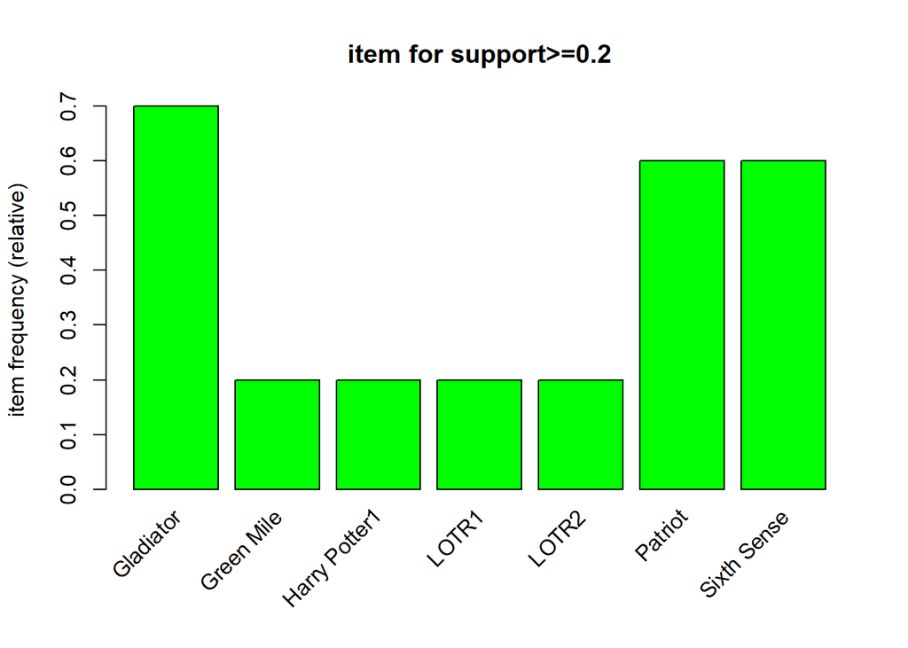

```r
# Bar chart for support>0.2
itemFrequencyPlot(dvd.trans,support=0.2,main="item for support>=0.2", col="green")
```

## 2. 연관규칙 분석 Ⅱ

### 데이터 설명(Groceries)

```r
# association rule analysis package
# install.packages("arules")
library(arules)

#association rule analysis
data("Groceries")

summary(Groceries)
```

```
## transactions as itemMatrix in sparse format with
##  9835 rows (elements/itemsets/transactions) and
##  169 columns (items) and a density of 0.02609146
##
## most frequent items:
##       whole milk other vegetables       rolls/buns             soda
##             2513             1903             1809             1715
##           yogurt          (Other)
##             1372            34055
##
## element (itemset/transaction) length distribution:
## sizes
##    1    2    3    4    5    6    7    8    9   10   11   12   13   14   15   16
## 2159 1643 1299 1005  855  645  545  438  350  246  182  117   78   77   55   46
##   17   18   19   20   21   22   23   24   26   27   28   29   32
##   29   14   14    9   11    4    6    1    1    1    1    3    1
##
##    Min. 1st Qu.  Median    Mean 3rd Qu.    Max.
##   1.000   2.000   3.000   4.409   6.000  32.000
##
## includes extended item information - examples:
##        labels  level2           level1
## 1 frankfurter sausage meat and sausage
## 2     sausage sausage meat and sausage
## 3  liver loaf sausage meat and sausage
```

### 지지도에 따른 시각화

- 지지도 5% 이상의 item 막대 그래프

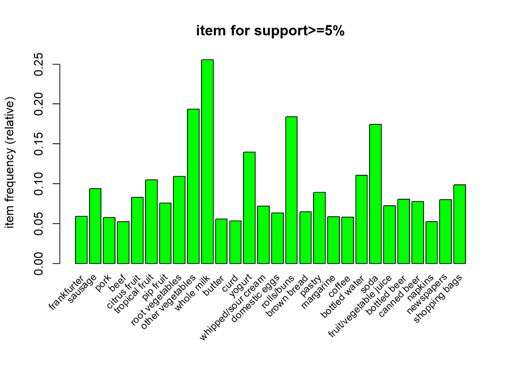

```r
# Bar chart for item with support>=5%
itemFrequencyPlot(Groceries,supp=0.05,main="item for support>=5%", col="green", cex=0.8)
```

- 지지도 상위 20개 막대 그래프

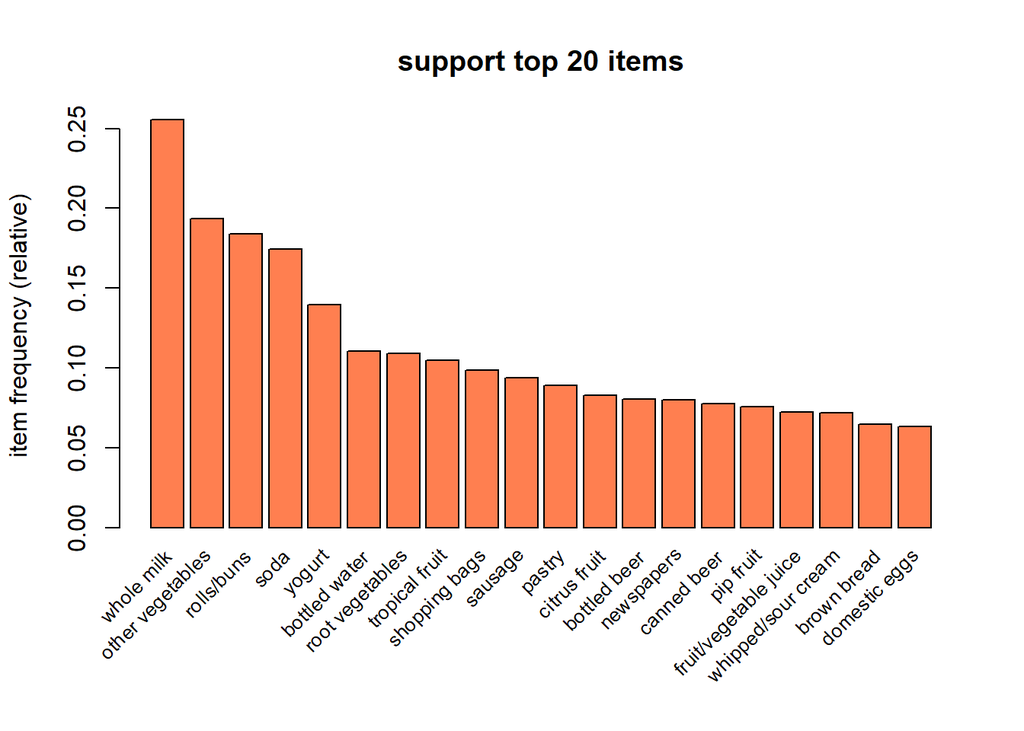

```r
# Bar chart for the top support 20 items
itemFrequencyPlot(Groceries,topN=20,main="support top 20 items", col="coral", cex=0.8)
```

### 연관규칙 분석결과

- 연관규칙분석
  - support, confidence, length는 minimum값으로 너무 높게 잡을 경우 연관규칙 분석이 되지 않음

```r
# Association rule with support>5%, confidence>20% in minimum length 2
Grocery_rule<-apriori(data=Groceries,
                      parameter = list(support=0.05,
                                       confidence = 0.20,
                                       minlen = 2))
```

```
## Apriori
##
## Parameter specification:
##  confidence minval smax arem  aval originalSupport maxtime support minlen
##         0.2    0.1    1 none FALSE            TRUE       5    0.05      2
##  maxlen target  ext
##      10  rules TRUE
##
## Algorithmic control:
##  filter tree heap memopt load sort verbose
##     0.1 TRUE TRUE  FALSE TRUE    2    TRUE
##
## Absolute minimum support count: 491
##
## set item appearances ...[0 item(s)] done [0.00s].
## set transactions ...[169 item(s), 9835 transaction(s)] done [0.00s].
## sorting and recoding items ... [28 item(s)] done [0.00s].
## creating transaction tree ... done [0.00s].
## checking subsets of size 1 2 done [0.00s].
## writing ... [6 rule(s)] done [0.00s].
## creating S4 object  ... done [0.00s].
```

```r
Grocery_rule
```

```
## set of 6 rules
```

- 연관규칙 조회 및 평가

```r
#analyzing result
summary(Grocery_rule)
```

```
## set of 6 rules
##
## rule length distribution (lhs + rhs):sizes
## 2
## 6
##
##    Min. 1st Qu.  Median    Mean 3rd Qu.    Max.
##       2       2       2       2       2       2
##
## summary of quality measures:
##     support          confidence        coverage           lift
##  Min.   :0.05602   Min.   :0.2193   Min.   :0.1395   Min.   :1.205
##  1st Qu.:0.05618   1st Qu.:0.2395   1st Qu.:0.1863   1st Qu.:1.282
##  Median :0.05663   Median :0.3004   Median :0.2245   Median :1.514
##  Mean   :0.06250   Mean   :0.3050   Mean   :0.2139   Mean   :1.430
##  3rd Qu.:0.07028   3rd Qu.:0.3670   3rd Qu.:0.2555   3rd Qu.:1.557
##  Max.   :0.07483   Max.   :0.4016   Max.   :0.2555   Max.   :1.572
##      count
##  Min.   :551.0
##  1st Qu.:552.5
##  Median :557.0
##  Mean   :614.7
##  3rd Qu.:691.2
##  Max.   :736.0
##
## mining info:
##       data ntransactions support confidence
##  Groceries          9835    0.05        0.2
```

```r
inspect(Grocery_rule)
```

```
##     lhs                   rhs                support    confidence coverage
## [1] {yogurt}           => {whole milk}       0.05602440 0.4016035  0.1395018
## [2] {whole milk}       => {yogurt}           0.05602440 0.2192598  0.2555160
## [3] {rolls/buns}       => {whole milk}       0.05663447 0.3079049  0.1839349
## [4] {whole milk}       => {rolls/buns}       0.05663447 0.2216474  0.2555160
## [5] {other vegetables} => {whole milk}       0.07483477 0.3867578  0.1934926
## [6] {whole milk}       => {other vegetables} 0.07483477 0.2928770  0.2555160
##     lift     count
## [1] 1.571735 551
## [2] 1.571735 551
## [3] 1.205032 557
## [4] 1.205032 557
## [5] 1.513634 736
## [6] 1.513634 736
```

- 결과 해석
  - 향상도 최솟값이 1보다 큼
  - 6개의 rules이 items 2개로 구성되어 있음
- 연관규칙: 향상도(lift) 순서로 정렬
  - sort() 함수를 통해 분석가가 보려는 기준으로 정렬하여 조회 가능

```r
# sorting by Lift
inspect(sort(Grocery_rule,by="lift"))
```

```
##     lhs                   rhs                support    confidence coverage
## [1] {yogurt}           => {whole milk}       0.05602440 0.4016035  0.1395018
## [2] {whole milk}       => {yogurt}           0.05602440 0.2192598  0.2555160
## [3] {other vegetables} => {whole milk}       0.07483477 0.3867578  0.1934926
## [4] {whole milk}       => {other vegetables} 0.07483477 0.2928770  0.2555160
## [5] {rolls/buns}       => {whole milk}       0.05663447 0.3079049  0.1839349
## [6] {whole milk}       => {rolls/buns}       0.05663447 0.2216474  0.2555160
##     lift     count
## [1] 1.571735 551
## [2] 1.571735 551
## [3] 1.513634 736
## [4] 1.513634 736
## [5] 1.205032 557
## [6] 1.205032 557
```

```r
# inspect(sort(Grocery_rule, by="support"))
```

- 연관규칙: 품목별 연관성 탐색
  - subset() 함수를 통해 원하는 item이 포함된 연관규칙만 선별해 조회 가능
  - %in%. %pin%, %ain% 등 옵션 이용 가능

```r
# searching association for interesting items
rule_interest<-subset(Grocery_rule, items %in% c("yogurt","whole milk"))
inspect(rule_interest)
```

```
##     lhs                   rhs                support    confidence coverage
## [1] {yogurt}           => {whole milk}       0.05602440 0.4016035  0.1395018
## [2] {whole milk}       => {yogurt}           0.05602440 0.2192598  0.2555160
## [3] {rolls/buns}       => {whole milk}       0.05663447 0.3079049  0.1839349
## [4] {whole milk}       => {rolls/buns}       0.05663447 0.2216474  0.2555160
## [5] {other vegetables} => {whole milk}       0.07483477 0.3867578  0.1934926
## [6] {whole milk}       => {other vegetables} 0.07483477 0.2928770  0.2555160
##     lift     count
## [1] 1.571735 551
## [2] 1.571735 551
## [3] 1.205032 557
## [4] 1.205032 557
## [5] 1.513634 736
## [6] 1.513634 736
```

- 연관규칙결과를 data.frame으로 저장

```r
# save as dataframe
Grocery_rule_df<-as(Grocery_rule,"data.frame")
Grocery_rule_df
```

```
##                                rules    support confidence  coverage     lift
## 1           {yogurt} => {whole milk} 0.05602440  0.4016035 0.1395018 1.571735
## 2           {whole milk} => {yogurt} 0.05602440  0.2192598 0.2555160 1.571735
## 3       {rolls/buns} => {whole milk} 0.05663447  0.3079049 0.1839349 1.205032
## 4       {whole milk} => {rolls/buns} 0.05663447  0.2216474 0.2555160 1.205032
## 5 {other vegetables} => {whole milk} 0.07483477  0.3867578 0.1934926 1.513634
## 6 {whole milk} => {other vegetables} 0.07483477  0.2928770 0.2555160 1.513634
##   count
## 1   551
## 2   551
## 3   557
## 4   557
## 5   736
## 6   736
```

```r
#saving results as csv file
write(Grocery_rule, file="Grocery_rule.csv",
      sep=",",
      quote=TRUE,
      row.names=FALSE)
```

## 3. 로지스틱회귀분석

### 로지스틱 회귀모형

- 로지스틱회귀분석(logistic regression)
  - 종속변수가 범주형인 경우 사용
    - 2개의 범주(양성/음성, 불량/양품 등) 또는 3개 이상의 범주를 다룸
    - 3개 이상 범주일 경우, 서열형 데이터(ordinal data), 명목형 데이터(nominal data)로 나누어 다른 모형 사용
  - log it(p) = β<sub>0</sub> + β<sub>1</sub>X
    - 회귀계수 β<sub>1</sub>의 의미가 선형회귀모형에서와는 다름
    - β<sub>1</sub>: X가 한 단위 증가할 때, logit(P)(승산비) 로그값의 증가분을 이야기함 → 승산비가 배로 증가함을 의미
- 데이터 살펴보기
  - 암 재발 확률 구하기
  - Y: Remiss(0,1)
  - 6 explanatory variables: risk factor related cancer remission(Cell, Smear, infill, Li, blast, temp)
- 로짓 변환을 통해 p헷(확률값)을 계산한 후, 확률값을 보고 0,5 또는 최적 임계치를 기준으로 구분하는 것
- 데이터 불러오기

```r
# remiss data
re <- read.csv("data/week14_3/remiss.csv")
head(re)
```

```
##   remiss cell smear infil  li blast  temp
## 1      1  0.8  0.83  0.66 1.9 1.100 0.996
## 2      1  0.9  0.36  0.32 1.4 0.740 0.992
## 3      0  0.8  0.88  0.70 0.8 0.176 0.982
## 4      0  1.0  0.87  0.87 0.7 1.053 0.986
## 5      1  0.9  0.75  0.68 1.3 0.519 0.980
## 6      0  1.0  0.65  0.65 0.6 0.519 0.982
```

```r
str(re)
```

```
## 'data.frame':    27 obs. of  7 variables:
##  $ remiss: int  1 1 0 0 1 0 1 0 0 0 ...
##  $ cell  : num  0.8 0.9 0.8 1 0.9 1 0.95 0.95 1 0.95 ...
##  $ smear : num  0.83 0.36 0.88 0.87 0.75 0.65 0.97 0.87 0.45 0.36 ...
##  $ infil : num  0.66 0.32 0.7 0.87 0.68 0.65 0.92 0.83 0.45 0.34 ...
##  $ li    : num  1.9 1.4 0.8 0.7 1.3 0.6 1 1.9 0.8 0.5 ...
##  $ blast : num  1.1 0.74 0.176 1.053 0.519 ...
##  $ temp  : num  0.996 0.992 0.982 0.986 0.98 ...
```

```r
attach(re)
```